# Warmup04 Sharon Hui

Sharon Hui

9/24/2018

```r
mkdir warmup04
cd warmup04
curl -O https://raw.githubusercontent.com/ucb-stat133/stat133-fall-2018/master/data/nba2018.csv
```

Below is the description of variables in `nba2018.csv`:

- `player`: first and last names of player
- `number`: number on jersey
- `team`: 3-letter team abbreviation
- `position`: player’s position
- `height`: height in feet-inches
- `weight`: weight in pounds
- `birth_date`: date of birth (“Month day, year”)
- `country`: 2-letter country abbreviation
- `experience`: years of experience in NBA (a value of R means rookie)
- `college`: attended college in USA
- `salary`: player salary in dollars
- `rank`: Rank of player in his team
- `age`: Age of Player at the start of February 1st of that season.
- `games`: Games Played furing regular season
- `sames_started`: Games Started
- `minutes`: Minutes Played during regular season
- `field_goals`: Field Goals Made
- `field_goals_atts`: Field Goal Attempts
- `field_goals_perc`: Field Goal Percentage
- `points3`: 3-Point Field Goals
- `points3_atts`: 3-Point Field Goal Attempts
- `points3_perc`: 3-Point Field Percentage
- `points2`: 2-Point Field Goals
- `points2_atts`: 2-Point Field Goal Attempts
- `points2_perc`: 2-Point Field Goal Percentage
- `effective_field_goal_perc`: Effective Field Goal Percentage
- `points1`: Free Throws Made
- `points1_atts`: Free Throw Attempts
- `points1_perc`: Free Throw Percentage
- `off_rebounds`: Offensive Rebounds
- `def_rebounds`: Defensive Rebounds
- `assists`: Assists
- `steals`: Steals
- `blocks`: Blocks
- `turnovers`: Turnovers
- `fouls`: Fouls
- `points`: Total points

#### 1) Import the data in R

```r
library(readr)
setwd("/Users/sharonhui/Desktop/warmup04")
nba <- read_csv("nba2018.csv", col_names = TRUE,
                col_types = list(player = "c",
                team = "c",
                height = "c",
                birth_date = "c",
                country = "c",
                experience = "c",
                college = "c",
                position = col_factor(levels = c('C', 'PF', 'PG', 'SF', 'SG')),

                salary = "d",
                field_goals_perc = "d",
                points3_perc = "d",
                points2_perc = "d",
                points1_perc = "d",
                effective_field_goal_perc = "d",

                number = "i",
                weight = "i",
                rank = "i",
                age = "i",
                games = "i",
                games_started = "i",
                minutes = "i",
                field_goals = "i",
                field_goals_atts = "i",
                points3 = "i",
                points3_atts = "i",
                points2 = "i",
                points2_atts = "i",
                points1 = "i",
                points1_atts = "i",
                off_rebounds = "i",
                def_rebounds = "i",
                assists = "i",
                steals = "i",
                blocks = "i",
                turnovers = "i",
                fouls = "i",
                points = "i"
                ))
str(nba)
```

```
## Classes 'tbl_df', 'tbl' and 'data.frame':    477 obs. of  38 variables:
##  $ player                   : chr  "Al Horford" "Amir Johnson" "Avery Bradley" "Demetrius Jackson" ...
##  $ number                   : int  42 90 0 9 30 4 99 13 7 8 ...
##  $ team                     : chr  "BOS" "BOS" "BOS" "BOS" ...
##  $ position                 : Factor w/ 5 levels "C","PF","PG",..: 1 2 5 3 4 3 4 5 4 2 ...
##  $ height                   : chr  "6-10" "6-9" "6-2" "6-1" ...
##  $ weight                   : int  245 240 180 201 205 185 235 215 225 231 ...
##  $ birth_date               : chr  "June 3, 1986" "May 1, 1987" "November 26, 1990" "September 7, 1994" ...
##  $ country                  : chr  "do" "us" "us" "us" ...
##  $ experience               : chr  "9" "11" "6" "R" ...
##  $ college                  : chr  "University of Florida" NA "University of Texas at Austin" "University of Notre Dame" ...
##  $ salary                   : num  26540100 12000000 8269663 1450000 1410598 ...
##  $ rank                     : int  4 6 5 15 11 1 3 13 8 10 ...
##  $ age                      : int  30 29 26 22 31 27 26 21 20 29 ...
##  $ games                    : int  68 80 55 5 47 76 72 29 78 78 ...
##  $ games_started            : int  68 77 55 0 0 76 72 0 20 6 ...
##  $ minutes                  : int  2193 1608 1835 17 538 2569 2335 220 1341 1232 ...
##  $ field_goals              : int  379 213 359 3 95 682 333 25 192 114 ...
##  $ field_goals_atts         : int  801 370 775 4 232 1473 720 58 423 262 ...
##  $ field_goals_perc         : num  0.473 0.576 0.463 0.75 0.409 0.463 0.463 0.431 0.454 0.435 ...
##  $ points3                  : int  86 27 108 1 39 245 157 12 46 45 ...
##  $ points3_atts             : int  242 66 277 1 111 646 394 35 135 130 ...
##  $ points3_perc             : num  0.355 0.409 0.39 1 0.351 0.379 0.398 0.343 0.341 0.346 ...
##  $ points2                  : int  293 186 251 2 56 437 176 13 146 69 ...
##  $ points2_atts             : int  559 304 498 3 121 827 326 23 288 132 ...
##  $ points2_perc             : num  0.524 0.612 0.504 0.667 0.463 0.528 0.54 0.565 0.507 0.523 ...
##  $ effective_field_goal_perc: num  0.527 0.612 0.533 0.875 0.494 0.546 0.572 0.534 0.508 0.521 ...
##  $ points1                  : int  108 67 68 3 33 590 176 6 85 26 ...
##  $ points1_atts             : int  135 100 93 6 41 649 217 9 124 37 ...
##  $ points1_perc             : num  0.8 0.67 0.731 0.5 0.805 0.909 0.811 0.667 0.685 0.703 ...
##  $ off_rebounds             : int  95 118 65 2 16 43 48 6 45 59 ...
##  $ def_rebounds             : int  370 248 269 2 68 162 367 20 175 213 ...
##  $ total_rebounds           : int  465 366 334 4 84 205 415 26 220 272 ...
##  $ assists                  : int  337 140 122 3 33 448 155 4 64 71 ...
##  $ steals                   : int  52 51 68 0 9 70 73 10 35 25 ...
##  $ blocks                   : int  86 62 11 0 7 13 23 2 18 17 ...
##  $ turnovers                : int  115 77 88 0 25 210 80 4 68 39 ...
##  $ fouls                    : int  138 211 141 0 48 167 161 15 142 122 ...
##  $ points                   : int  952 520 894 10 262 2199 999 68 515 299 ...
##  - attr(*, "problems")=Classes 'tbl_df', 'tbl' and 'data.frame': 1 obs. of  5 variables:
```

[output cut: 74 more lines]

[output not shown]

```r
# read_csv()'s default for column types is integers.
```

#### 2) Right after importing the data

`experience` should be of type character because of the presence of the R values that indicate rookie players. Replace all the occurrences of `"R"` with `0`, and then convert the entire column into integers. Display the `summary()` of this column.

```r
nba$experience[nba$experience == "R"] <- 0
nba$experience <- as.integer(nba$experience)
summary(nba$experience)
```

```
##    Min. 1st Qu.  Median    Mean 3rd Qu.    Max.
##   0.000   1.000   4.000   4.662   7.000  18.000
```

`salary` is originally measured in dollars. Transform salary so that you have salaries in millions: e.g. 1000000 should be converted to 1. Display the `summary()` of this column.

```r
nba$salary <- nba$salary/1000000
summary(nba$salary)
```

```
##      Min.   1st Qu.    Median      Mean   3rd Qu.      Max.
##  0.005145  1.050961  3.000000  5.804697  8.269663 30.963450
```

`position` should be a factor with 5 levels: `'C'`, `'PF'`, `'PG'`, `'SF'`, `'SG'`. Relabel these factors using more descriptive names (see below). Display the frequencies of the relabeled factor with `table()`.

```r
levels(nba$position) <- c("center", "power_fwd", "point_guard", "small_fwd", "shoot_guard")
table(nba$position)
```

```
##
##      center   power_fwd point_guard   small_fwd shoot_guard
##          97          98          96          84         102
```

#### 3) A bit of subscripting (i.e. indexing, slicing, subsetting)

- How many players went to UCLA (“University of California, Los Angeles”)?

14 players went to UCLA (“University of California, Los Angeles”).

```r
length(nba$player[nba$college == "University of California, Los Angeles"][!is.na(nba$player[nba$college == "University of California, Los Angeles"])])
```

```
## [1] 14
```

```r
#another way to do this

NROW(nba$player[which(nba$college == "University of California, Los Angeles")])
```

```
## [1] 14
```

- How many players went to Cal (“University of California, Berkeley”)?

0 players went to Cal (“University of California, Berkeley”).

```r
length(nba$player[nba$college == "University of California, Berkeley"][!is.na(nba$player[nba$college == "University of California, Berkeley"])])
```

```
## [1] 0
```

```r
#another way is

NROW(nba$player[which(nba$college == "University of California, Berkeley")])
```

```
## [1] 0
```

- What’s the largest weight value?

290 is the largest weight value.

```r
nba$weight[which.max(nba$weight)]
```

```
## [1] 290
```

- Who are the players with the largest weight value?

The player with the largest weight value is Boban Marjanovic.

```r
nba$player[which.max(nba$weight)]
```

```
## [1] "Boban Marjanovic"
```

- What’s the overall average weight?

The overall average weight is 219.9119 pounds.

```r
mean(nba$weight)
```

```
## [1] 219.9119
```

- What is the median salary of all players?

The median salary of all players is 3 million dollars.

```r
#The median value is in millions
median(nba$salary)
```

```
## [1] 3
```

- What is the median salary of the players with 10 years of experience or more?

4.8375 million dollars is the median salary of the players with 10 years of experience or more.

```r
#The median value is in millions
median(nba$salary[nba$experience >= 10])
```

```
## [1] 4.8375
```

- What is the median salary of Shooting Guards (SG) and Point Guards (PG)?

2.789697 million dollars is the median salary of Shooting Guards (SG) and Point Guards (PG).

```r
#The median value is in millions
median(nba$salary[(nba$position == "point_guard") | nba$position == "shoot_guard"])
```

```
## [1] 2.789697
```

The median salary of the shooting guards is 2.884406.

```r
#The median value is in millions
median(nba$salary[nba$position == "shoot_guard"])
```

```
## [1] 2.884406
```

The median salary of the point guards is 2.704291.

```r
#The median value is in millions
median(nba$salary[nba$position == "point_guard"])
```

```
## [1] 2.704291
```

- What is the median salary of Power Forwards (PF), 30 years or older, weighing 240 pounds or more?

8 million dollars is the median salary of Power Forwards (PF), 30 years or older, weighing 240 pounds or more.

```r
median(nba$salary[(nba$position == "power_fwd") & (nba$age >= 30) & (nba$weight >= 240)])
```

```
## [1] 8
```

- Create a data frame `gsw` with the player name, position, height, weight, and age of Golden State Warriors (GSW). Display this data frame.

```r
gsw <- data.frame(nba$player[nba$team == "GSW"], nba$position[nba$team == "GSW"], nba$height[nba$team == "GSW"], nba$weight[nba$team == "GSW"], nba$age[nba$team == "GSW"])
names(gsw) <- c("Player", "Position", "Height", "Weight", "Age")
gsw
```

```
##                  Player    Position Height Weight Age
## 1      Anderson Varejao      center   6-10    273  34
## 2        Andre Iguodala   small_fwd    6-6    215  33
## 3          Damian Jones      center    7-0    245  21
## 4            David West      center    6-9    250  36
## 5        Draymond Green   power_fwd    6-7    230  26
## 6             Ian Clark shoot_guard    6-3    175  25
## 7  James Michael McAdoo   power_fwd    6-9    230  24
## 8          JaVale McGee      center    7-0    270  29
## 9          Kevin Durant   power_fwd    6-9    240  28
## 10         Kevon Looney      center    6-9    220  20
## 11        Klay Thompson shoot_guard    6-7    215  26
## 12          Matt Barnes   small_fwd    6-7    226  36
## 13        Patrick McCaw shoot_guard    6-7    185  21
## 14     Shaun Livingston point_guard    6-7    192  31
## 15        Stephen Curry point_guard    6-3    190  28
## 16        Zaza Pachulia      center   6-11    270  32
```

#### 4) Performance of players

Performance of NBA players can be measured in various ways. Perhaps the most popular performance measure is known as the “Efficiency” statistic, simply referred to as EFF. According to Wikipedia, EFF computes performance as an index that takes into account basic individual statistics: points, rebounds, assists, steals, blocks, turnovers, and shot attempts (per game). It is derived by a simple formula:

According to [Wikipedia](https://en.wikipedia.org/wiki/Basketball_statistics), EFF computes performance as an index that takes into account basic individual statistics: points, rebounds, assists, steals, blocks, turnovers, and shot attempts (per game). It is derived by a simple formula:

`EFF = (PTS + REB + AST + STL + BLK - Missed FG - Missed FT - TO) / GP`

- `EFF`: efficiency
- `PTS`: total points
- `REB`: total rebounds
- `AST`: assists
- `STL`: steals
- `BLK`: blocks
- `Missed FG`: missed field goals
- `Missed FT`: missed free throws
- `TO`: turnovers
- `GP`: games played

You will have to compute the efficiency (EFF) for each player. In order to do this, you’ll have to add the following variables to the main data frame:

- `missed_field_goals` (missed field goals)
- `missed_free_throws` (missed free throws)
- `rebounds` (total rebounds: offensive and defensive)
- `mins_game` (minutes per game; NOT to be used when calculating EFF)

```r
nba$missed_field_goals <- (nba$field_goals_atts - nba$field_goals)
nba$missed_free_throws <- (nba$points1_atts - nba$points1)
nba$rebounds <- (nba$off_rebounds + nba$def_rebounds)
nba$mins_games <- (nba$minutes/nba$games)
```

Once you have all the necessary statistics, add a column efficiency to the data frame using the formula provided above.

```r
nba$efficiency <- ((nba$points + nba$rebounds + nba$assists + nba$steals + nba$blocks - nba$missed_field_goals - nba$missed_free_throws - nba$turnovers))/nba$games
```

Compute `summary()` statistics for efficiency and graph its histogram. Add color to the bars in the histograms, and make sure it includes descriptive axis labels, as well as a title.

```r
summary(nba$efficiency)
```

```
##    Min. 1st Qu.  Median    Mean 3rd Qu.    Max.
## -0.6667  5.0000  8.3472  9.5788 12.6066 33.8272
```

```r
sd(nba$efficiency)
```

```
## [1] 6.420014
```

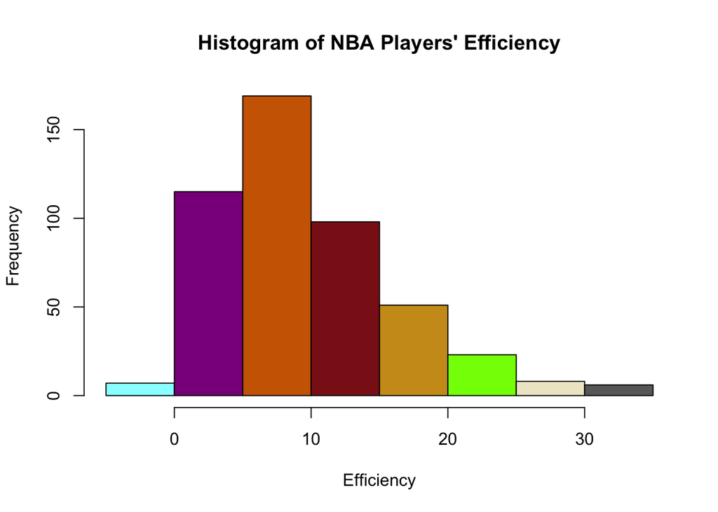

```r
hist(nba$efficiency, xlab = "Efficiency", ylab = "Frequency", main = "Histogram of NBA Players' Efficiency", col = c("darkslategray1", "darkmagenta", "darkorange3", "firebrick4", "goldenrod3", "chartreuse", "cornsilk2", "dimgrey"))
```

Display the player name, team, salary, and efficiency value of the top-10 players by EFF in decreasing order (display this information in a data frame). Did you find players with a negative EFF? If yes, display their names.

```r
firstten <- (data.frame(nba$player, nba$team, nba$salary, nba$efficiency))
topten <- firstten[with(firstten, order(-nba.efficiency)),]
names(topten) <- (c("Player", "Team", "Salary", "Efficiency"))
head(topten, n = 10)
```

```
##                    Player Team    Salary Efficiency
## 332     Russell Westbrook  OKC 26.540100   33.82716
## 283          James Harden  HOU 26.540100   32.38272
## 384         Anthony Davis  NOP 22.116750   31.14667
## 31           LeBron James  CLE 30.963450   30.95946
## 440    Karl-Anthony Towns  MIN  5.960160   30.30488
## 254          Kevin Durant  GSW 26.540100   30.19355
## 83  Giannis Antetokounmpo  MIL  2.995421   28.37500
## 387      DeMarcus Cousins  NOP 16.957900   27.88235
## 124          Jimmy Butler  CHI 17.552209   25.60526
## 134      Hassan Whiteside  MIA 22.116750   25.37662
```

```r
# Another method to obtain the top ten
top_ten_1 <- data.frame(
  Player = head(nba$player[order(nba$efficiency, decreasing = TRUE)], n = 10),
  Team = head(nba$team[order(nba$efficiency, decreasing = TRUE)], n = 10),
  Salary = head(nba$salary[order(nba$efficiency, decreasing = TRUE)], n = 10),
  Efficiency = head(sort(nba$efficiency, decreasing = TRUE), n = 10)
)
top_ten_1
```

```
##                   Player Team    Salary Efficiency
## 1      Russell Westbrook  OKC 26.540100   33.82716
## 2           James Harden  HOU 26.540100   32.38272
## 3          Anthony Davis  NOP 22.116750   31.14667
## 4           LeBron James  CLE 30.963450   30.95946
## 5     Karl-Anthony Towns  MIN  5.960160   30.30488
## 6           Kevin Durant  GSW 26.540100   30.19355
## 7  Giannis Antetokounmpo  MIL  2.995421   28.37500
## 8       DeMarcus Cousins  NOP 16.957900   27.88235
## 9           Jimmy Butler  CHI 17.552209   25.60526
## 10      Hassan Whiteside  MIA 22.116750   25.37662
```

```r
nba$player[nba$efficiency < 0]
```

```
## [1] "Gary Neal"       "Axel Toupane"    "Patricio Garino" "Ben Bentil"
```

The players with the negative efficiency are “Gary Neal,” “Axel Toupane,” “Patricio Garino,” and “Ben Bentil.”

#### 5) Further Exploration

Answer the following questions, and provide numerical and/or graphical evidence to support your answer:

- The more efficient a player is, the higher his salary?

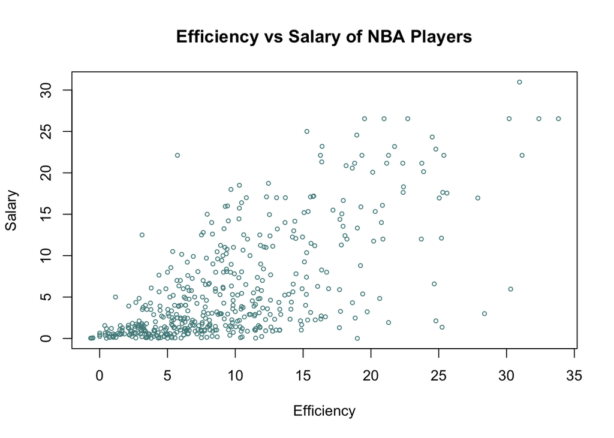

```r
plot(nba$efficiency, nba$salary, main = "Efficiency vs Salary of NBA Players", xlab = "Efficiency", ylab = "Salary", cex = 0.6, col = "darkslategray4")
```

```r
cor(nba$efficiency, nba$salary)
```

```
## [1] 0.6732908
```

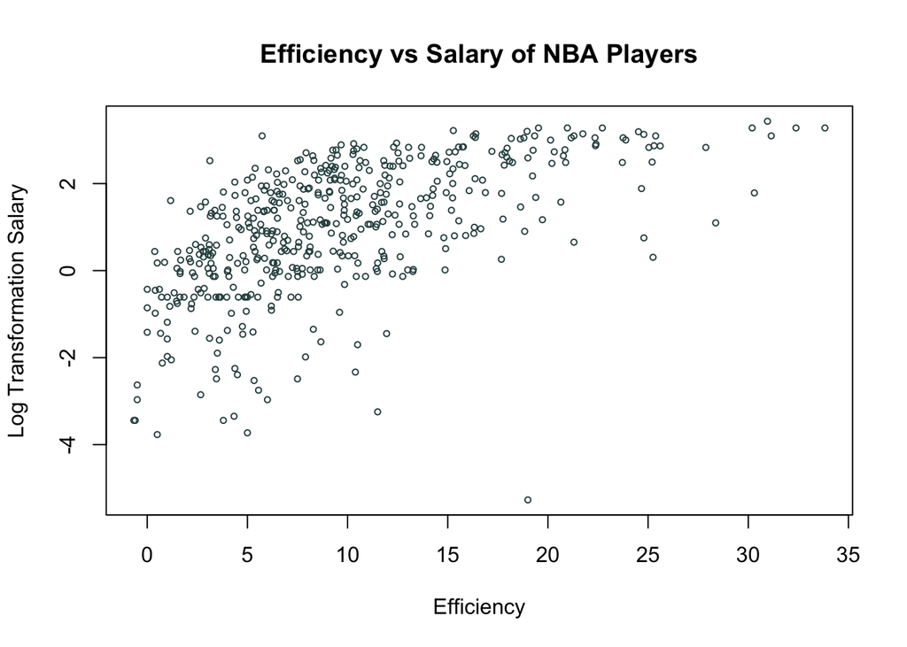

```r
plot(nba$efficiency, log(nba$salary), main = "Efficiency vs Salary of NBA Players", xlab = "Efficiency", ylab = "Log Transformation Salary", cex = 0.6, col = "darkslategrey")
```

I decided to not use the log transformed values of NBA salaries because the plot that was created using `plot(nba$efficiency, log(nba$salary))` did not seem to be linear.

- As players get older, do they tend to become more efficient?

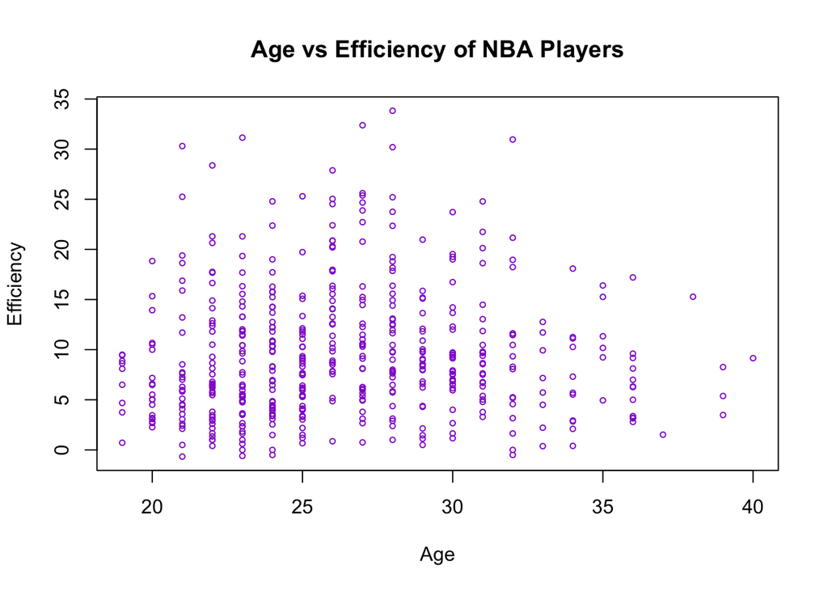

```r
plot(nba$age, nba$efficiency, main = "Age vs Efficiency of NBA Players", xlab = "Age", ylab = "Efficiency", cex = 0.6, col = "darkviolet")
```

```r
cor(nba$age, nba$efficiency)
```

```
## [1] 0.0432995
```

- Does the rank of a player seem to be associated with his efficiency (i.e. the more important the rank, the more efficient)?

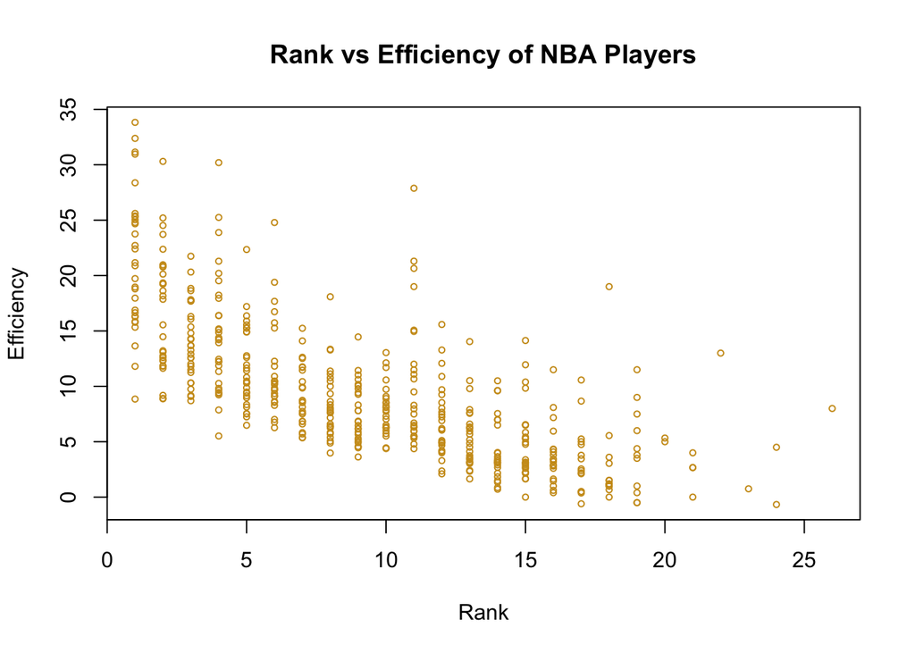

```r
plot(nba$rank, nba$efficiency, main = "Rank vs Efficiency of NBA Players", xlab = "Rank", ylab = "Efficiency", cex = 0.6, col = "goldenrod3")
```

```r
cor(nba$rank, nba$efficiency)
```

```
## [1] -0.7163952
```

#### 6) Comments and Reflections

Reflect on what was hard/easy, problems you solved, helpful tutorials you read, etc.

How much time did it take to complete this HW? What things were hard, even though you saw them in class/lab? What was easy(-ish) even though we haven’t done it in class/lab? Did you need help to complete the assignment? If so, what kind of help? What was the most time consuming part? Was there anything that you did not understand? or fully grasped? Was there anything frustrating in particular?

- I took about 6 hours to complete this homework.
- One difficult part of the lab included subsetting to find out how many players went to UCLA (“University of California, Los Angeles”) and how many of the players went to Cal (“University of California, Berkeley”). Typically, I used length to find out how many players went to call, but kept obtaining the incorrect number until I realized that I needed to prevent R from counting the “FALSE” elements.
- Another difficult part of the lab was importing the data and specfying the data-type for each column because I kept getting “1 parsing failure”. Several people in the class were obtaining this warning.
- One thing that was fairly easy even though we haven’t done it in class/lab was using numerical and/or graphical evidence to support your answer. Although we have not discussed how to do this explicitly in class, we can check how closely related two variables are by looking at the scatterplot to check if the relationship between two variables is linear. We can also use a scatterplot and correlation coefficient to examine if the relationship is positive or negative.
- I needed help to complete the assignment due to the parsing failure warning that I was given. After using `read_csv`, I was not able to do anything to remove the parsing error. I went onto Piazza and noticed that several other people were obtaining the same warning. `Derrick Williams` has a number that went from 3 to 32.
- The most time-consuming part was trying to understand why I was obtaining the parsing failure, but a few other students did not have the parsing failure.
- One thing that I have not fully understood/grasped was the parsing failure and why it worked for some students but not for others.
- The most frustrating part of the assignment was understanding the assignment. During the lab discussion, since I had finished Lab 04, I decided to start on Warm Up 04. I spent most of my time trying to understand the how the `read_csv` and `col_types` was used and why I was obtaining the parsing failure warning.